# **Attitude vs. Architecture: A Tale of Two Groups**

Russ Yoon, Zheng Fu

# **Introduction**

What actually drives collective behavior change? Social psychology and cultural sociology, emphasizes individual attitudes — the idea that if people are open-minded enough, willing to update their beliefs, and exposed to new information, coordination will eventually follow (Axelrod, 1997; Centola & Macy, 2007). Another tradition, coming more from network sociology and complexity science, argues that it is the structure of social ties that matters most: who talks to whom, how often, and through what channels (Granovetter, 1973; Watts & Strogatz, 1998). In practice, both probably matter when two groups must reach a shared convention — whether on a technical standard, a workplace norm, or a social practice.

This paper speaks directly to this question. We set up a stylized world with two groups of agents that are almost identical: same size, same decision-making logic, same information environment, but differ in one key way that one group is more flexible about revising its position, and the other is more resistant. We assume it less as two groups with fundamentally different values, and more as two groups sitting at different points on a spectrum of openness to change. Neither group is inherently correct, and both stand to benefit from reaching a shared convention. We begin with a symmetric 50/50 population split as our baseline, then extend the design to ask what happens when the flexible group becomes the majority, and we wondering whether smaller stubborn group will hinder the group coordination.

To isolate the effect of network structure from the effect of group disposition, we run the same model across three distinct communication architectures: random network, scale-free network dominated by high-degree hubs, and clustered network built around tight sub-communities. Everything else stays fixed. This lets us ask a clean question: if we hold the agents constant and only change how they are connected, does the outcome change? And if so, by how much, relative to changing how stubborn the resistant group actually is?

## **Assumption**

The models have a few simplifying assumptions:

First, agents communicate only with one immediate neighbors by email, which means nobody has access to the global state, and decision are formed entirely from local messages.

Second, the two groups are symmetric in every respect except their preference strength: Humans carry a lower own-side bonus (? = 0.3) and are therefore willing to switch under moderate social pressure, while Aliens carry a higher bonus (? = 0.9) and require a much stronger signal before they abandon their native convention.

Third, the network is fixed throughout the simulation, which means agents do not rewire their connections in response to disagreement.

Fourth, agents are forward-looking: rather than simply reacting to the current signal, they simulate how their neighbors might respond to their own choice over a short horizon, and pick the side that maximises their expected payoff.

Finally, all coordination is simple, we assume there are no costs to switching beyond the preference penalty, and no external authority pushing either group toward a particular outcome.

These assumptions are deliberately strong, which will allow us to isolate the mechanisms cleanly: when the only thing that varies is network structure or preference strength, which one drives the result?

## **Formalization**

### Setup

$N$ agents on a graph. The message an agent sends is its current side $s_i$.

**Global information** (true population state, not observed by agents):

$$f_i^s = \frac{\#\{\text{agents on side } s\}}{\#\{\text{agents}\}}, \qquad x_i = \max(f_i^R, f_i^L) \quad \text{(dominance)}$$

**Local information** (what the agent actually has): agent $i$ stores each neighbor's latest reported side, overwriting on repeat contact.

$$\hat f_i^{\,s} = \frac{\#\{\text{known neighbors on side } s\}}{\#\{\text{known neighbors}\}}, \qquad \hat x_i = \max(\hat f_i^R, \hat f_i^L) \quad \text{(estimated dominance)}$$

### Utility — Three Terms

$$U_i(s) = \alpha\,(0.5 - x_i)^2 + \beta\,(2 f_i^{\,s} - 1) + \gamma_i\,\mathbb{1}[s = \text{native}_i]$$

- $\alpha\,(0.5 - x_i)^2$ — **shared benefit:** a public good from having any dominant convention; side-independent.
- $\beta\,(2 f_i^{\,s} - 1)$ — **coordination pull:** gain from holding the side your neighbors favor.
- $\gamma_i\,\mathbb{1}[s = \text{native}_i]$ — **own-side preference:** fixed bonus for your native side; $\gamma_i$ may differ for Humans vs. Aliens.

**Myopic flip rule:** leave the native side only when

$$2\beta\,|2\hat f_i^s - 1| > \gamma_i \quad\Rightarrow\quad \text{stay-native band of width } \gamma_i / 2\beta$$

### Forward-Looking Agents

Agents weigh the value of taking and holding a side:

$$s_i(t+1) = \arg\max_s V_i(s), \qquad V_i(s) = \sum_{\tau=0}^{H-1} \delta^\tau\, U_i\!\left(s \mid \hat f_i^{\,s} \text{ at step } \tau\right)$$

**Rollout.** Assume $i$ commits to side $s$; predict each neighbor $j$'s drift toward it:

$$p_R[j] \mathrel{+}= \frac{1}{k_i}\,(1 - \hat\theta_{ij})\,(\text{tgt} - p_R[j])$$

- $1/k_i$ — **contact probability:** $i$ reaches only one neighbor per round.
- $(1 - \hat\theta_{ij})$ — **susceptibility:** how much $j$ moves once contacted.

**Estimate of stubbornness** $\hat\theta_{ij}$ — learned from the persistence of $j$'s reported side:

$$\hat\theta_{ij} = 1 - \frac{\#\{\text{side changes in } j\text{'s reports}\}}{\#\{\text{emails from } j\} - 1}$$

- $\hat\theta_{ij} \to 1$: $j$ never switches (stubborn); $\hat\theta_{ij} \to 0$: $j$ flips freely.
- Positively correlated with $\gamma_i$ (native preference) and is a proxy estimate.
- Recruitment becomes an endogenous motive.

### Network

To answer the question, we compare convention emergence across three types of networks, which provides different structural assumption about how agents communicate.

The first is a Stochastic Block Model (SBM), which serves as our baseline (edges are drawn independently at random within and across groups)

The second is a Scale-Free network, which produces a small number of high-degree hub agents alongside many low-degree peripheral agents; cross-group edges are restricted to the top-degree hubs of each group, inter-group information flows through a narrow set of bridge nodes.

The third is a Clustered network, in which each group is further subdivided into tight sub-communities connected by dense intra-cluster edges and sparse inter-cluster edges, with very sparse cross-group links.

# Results

### **50% population for each group with extreme different preference**

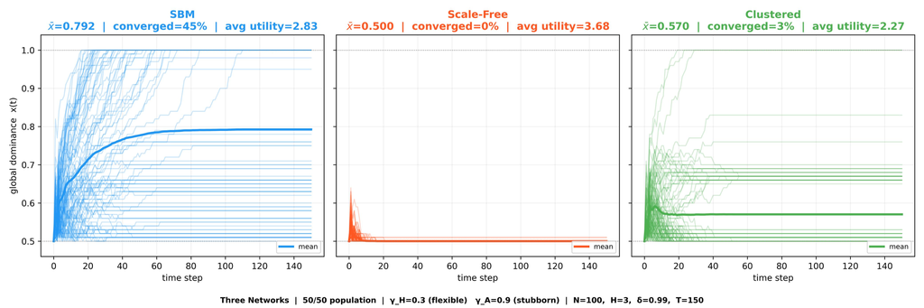

### **50% population for each group with both low preference**

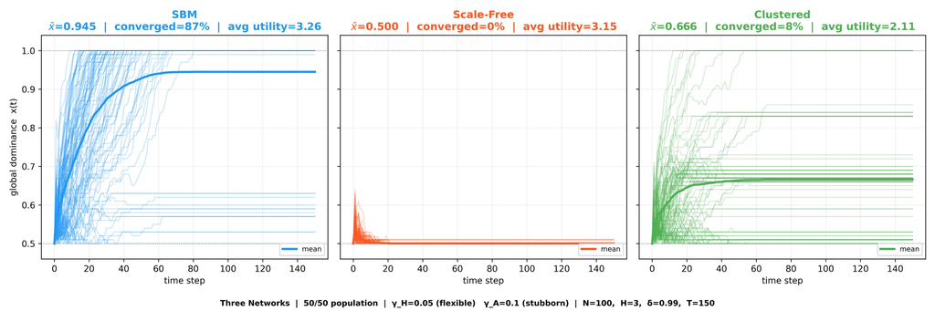

By comparing the same three networks under two different preference level/gap conditions. The top figure uses a larger gap (?_H=0.3, ?_A=0.9) while the bottom reduces both values significantly (?_H=0.05, ?_A=0.1), bringing the two groups much closer together in terms of stubbornness.

The pattern across networks stays consistent — Scale-Free locks at x=0.5 in both cases, confirming once again that its failure is structural and unresponsive to attitude change. What does shift is the magnitude of success in the other two networks: when the preference gap narrows, SBM jumps from 45% to 87% convergence and Clustered improves from 3% to 8%, suggesting that reducing stubbornness does help, but only where the network already allows cross-group signals to flow. The core takeaway is that attitude change and network structure are not substitutes, we will need both, and in the wrong network, attitude change alone buys you very little.

One more thing worth noting is the average utility numbers, which tell a slightly different story. In the top figure (larger gap), Scale-Free actually has the highest utility (3.68) despite achieving zero consensus? which seems to be counterintuitive, but makes sense because our utility function includes a bonus for sitting on your native side. Agents who never switch collect that bonus every period, so a perfectly polarized outcome can still feel individually satisfying even though it is collectively inefficient.

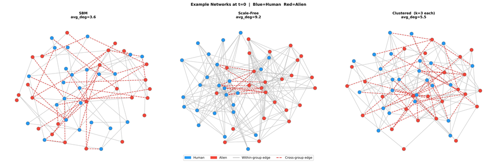

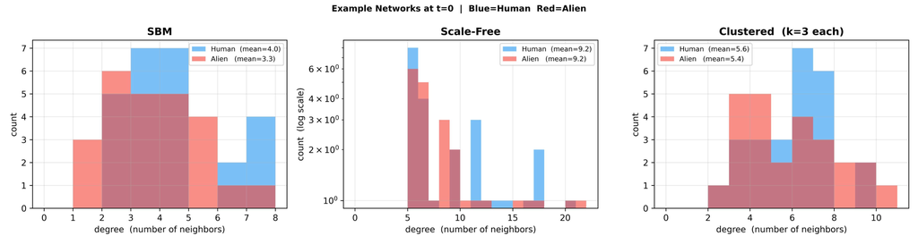

This is the degree distribution of Human and Alien nodes in each network. In the SBM, both groups have low and similar average degrees, with most nodes having between 2 and 6 neighbors, which means the structural symmetry of the baseline network. In the Scale-Free network, both groups again share the same mean degree (9.2), but the distribution has a long right tail stretching to degree 22, on log scale — most nodes have only 5–6 neighbors while some hubs are connected to far more. Importantly, both Humans and Aliens produce hubs in roughly equal numbers, but because Human hubs are flexible (?=0.05) and Alien hubs are stubborn (?=0.1), the structural equivalence masks a behavioral asymmetry: Human hubs switch early, while Alien hubs hold firm and anchor the rest of their group. For the clustered network, degrees are moderate and tightly distributed(around 5.5), reflecting the dense intra-cluster wiring.

### **Changing windows for attitudes and group size**

To answer the question that why coordination failure, we conducted two more analysis with changing windows for parameters.

The first asks whether it is a size problem, in other words, does the stubborn group just need to be outnumbered badly enough? The second asks whether it is an attitude problem, does making the stubborn group more flexible actually help? By varying population mix in one figure and stubbornness in the other, while keeping everything else fixed, we can see which lever actually moves the outcome and whether that answer changes depending on the network.

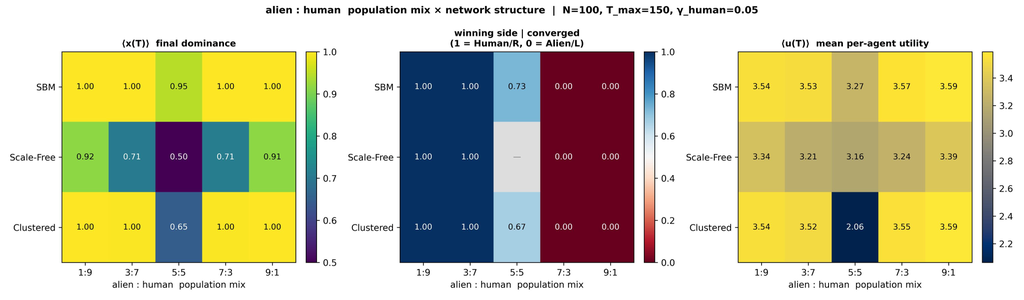

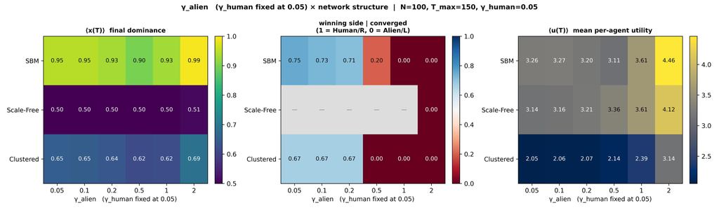

# Conclusion

The findings speak directly to the debate we opened with. The tradition that emphasizes individual attitudes: openness, willingness to update, exposure to new information, is incomplete. It implicitly assumes a communication environment where signals can actually reach the people who need to receive them. When that assumption fails, as it does in hub-dominated or echo-chamber networks, attitude change alone cannot move the outcome. The tradition that emphasizes network structure turns out to be closer to the binding constraint, at least in the settings we tested.

The practical implication follows naturally. If two groups are struggling to converge on a shared norm(whether in a workplace, a policy arena, or across cultural communities), the instinct is often to focus on persuasion: make one side more open, reduce the preference gap, change the incentives. Our results suggest that this instinct may be misplaced.

The more productive question is structural: are the two groups actually talking to each other, through channels that are broad enough and distributed enough to let minority signals accumulate? If the answer is no, changing attitudes is unlikely to help much. Building bridges matters more than changing minds.

# Futhur Researches

**1. Dynamic networks** The current network is fixed (edges never change). In reality, people rewire their social connections over time, we are thinking to add it and create a feedback loop where polarization reinforces itself by destroying cross-group links, so the trap is harder to escape.

**2. Sliding window for ? (preference change)** Currently ? is a fixed constant(an agent's attachment to its native side never weakens no matter how much contradicting evidence accumulates). We can let ? decay/increase as the agent receives more/less cross-group signals, modelling the idea that prolonged exposure to the other side gradually softens cultural resistance/perference.

# Applications

**1. Immigration and Cultural Integration** When immigrant communities are densely connected internally (like the Clustered network), mainstream culture hardly goes deep enough to shift behavior, even if the host society is fully open. The model suggests that physical and social mixing policies matter more than attitude change campaigns.

**2. Political Polarization** A small number of stubborn opinion leaders (hubs) can lock an entire group into one position, regardless of how moderate the majority is. This mirrors how extreme voices on social media anchor group opinion, removing or moderating a few key hubs may do more than trying to change millions of ordinary users.

## Reference

**Robert Axelrod (1997)**. The dissemination of culture: A model with local convergence and global polarization. Journal of Conflict Resolution, 41(2), 203–226. https://doi.org/10.1177/0022002797041002001

**Damon Centola, & Michael Macy (2007)**. Complex contagions and the weakness of long ties. American Journal of Sociology, 113(3), 702–734. https://doi.org/10.1086/521848

**Mark Granovetter (1973)**. The strength of weak ties. American Journal of Sociology, 78(6), 1360–1380. https://doi.org/10.1086/225469

**Duncan J. Watts, & Steven Strogatz (1998). Collective dynamics of ‘small-world’ networks.** Nature, 393(6684), 440–442. https://doi.org/10.1038/30918